# Risk Factor Analysis

## Outcome Variable

**Outcome Variable:** stunted

## Predictor Variables

**Intervention Variable:** impsan

**Adjustment Set:**

- arm
- sex
- W_mage
- meducyrs
- feducyrs
- hhwealth_quart
- hfoodsec
- W_mhtcm
- W_mwtkg
- W_mbmi
- W_nrooms
- W_nchldlt5
- W_parity
- impfloor
- safeh20
- delta_W_mage
- delta_meducyrs
- delta_feducyrs
- delta_hhwealth_quart
- delta_hfoodsec
- delta_W_mhtcm
- delta_W_mwtkg
- delta_W_mbmi
- delta_W_nrooms
- delta_W_nchldlt5
- delta_W_parity
- delta_impfloor
- delta_safeh20

## Stratifying Variables

The analysis was stratified on these variable(s):

- agecat
- studyid
- country

## Data Summary

| agecat | studyid | country | impsan | stunted | n_cell | n |
| --- | --- | --- | --- | --- | --- | --- |
| Birth | COHORTS | GUATEMALA | 1 | 0 | 42 | 491 |
| Birth | COHORTS | GUATEMALA | 1 | 1 | 3 | 491 |
| Birth | COHORTS | GUATEMALA | 0 | 0 | 416 | 491 |
| Birth | COHORTS | GUATEMALA | 0 | 1 | 30 | 491 |
| Birth | COHORTS | INDIA | 1 | 0 | 1593 | 4776 |
| Birth | COHORTS | INDIA | 1 | 1 | 174 | 4776 |
| Birth | COHORTS | INDIA | 0 | 0 | 2618 | 4776 |
| Birth | COHORTS | INDIA | 0 | 1 | 391 | 4776 |
| Birth | COHORTS | PHILIPPINES | 1 | 0 | 176 | 1191 |
| Birth | COHORTS | PHILIPPINES | 1 | 1 | 2 | 1191 |
| Birth | COHORTS | PHILIPPINES | 0 | 0 | 936 | 1191 |
| Birth | COHORTS | PHILIPPINES | 0 | 1 | 77 | 1191 |
| Birth | CONTENT | PERU | 1 | 0 | 1 | 2 |
| Birth | CONTENT | PERU | 1 | 1 | 0 | 2 |
| Birth | CONTENT | PERU | 0 | 0 | 1 | 2 |
| Birth | CONTENT | PERU | 0 | 1 | 0 | 2 |
| Birth | JiVitA-3 | BANGLADESH | 1 | 0 | 10471 | 22431 |
| Birth | JiVitA-3 | BANGLADESH | 1 | 1 | 4749 | 22431 |
| Birth | JiVitA-3 | BANGLADESH | 0 | 0 | 4577 | 22431 |
| Birth | JiVitA-3 | BANGLADESH | 0 | 1 | 2634 | 22431 |
| Birth | JiVitA-4 | BANGLADESH | 1 | 0 | 1541 | 2820 |
| Birth | JiVitA-4 | BANGLADESH | 1 | 1 | 640 | 2820 |
| Birth | JiVitA-4 | BANGLADESH | 0 | 0 | 423 | 2820 |
| Birth | JiVitA-4 | BANGLADESH | 0 | 1 | 216 | 2820 |
| Birth | MAL-ED | BANGLADESH | 1 | 0 | 147 | 213 |
| Birth | MAL-ED | BANGLADESH | 1 | 1 | 32 | 213 |
| Birth | MAL-ED | BANGLADESH | 0 | 0 | 29 | 213 |
| Birth | MAL-ED | BANGLADESH | 0 | 1 | 5 | 213 |
| Birth | MAL-ED | BRAZIL | 1 | 0 | 50 | 60 |
| Birth | MAL-ED | BRAZIL | 1 | 1 | 9 | 60 |

[output cut: 170 more lines]

The following strata were considered:

- agecat: 24 months, studyid: COHORTS, country: GUATEMALA
- agecat: 24 months, studyid: COHORTS, country: INDIA
- agecat: 24 months, studyid: COHORTS, country: PHILIPPINES
- agecat: 24 months, studyid: CONTENT, country: PERU
- agecat: 24 months, studyid: JiVitA-3, country: BANGLADESH
- agecat: 24 months, studyid: JiVitA-4, country: BANGLADESH
- agecat: 24 months, studyid: LCNI-5, country: MALAWI
- agecat: 24 months, studyid: MAL-ED, country: BANGLADESH
- agecat: 24 months, studyid: MAL-ED, country: BRAZIL
- agecat: 24 months, studyid: MAL-ED, country: INDIA
- agecat: 24 months, studyid: MAL-ED, country: NEPAL
- agecat: 24 months, studyid: MAL-ED, country: PERU
- agecat: 24 months, studyid: MAL-ED, country: SOUTH AFRICA
- agecat: 24 months, studyid: MAL-ED, country: TANZANIA, UNITED REPUBLIC OF
- agecat: 24 months, studyid: NIH-Birth, country: BANGLADESH
- agecat: 24 months, studyid: NIH-Crypto, country: BANGLADESH
- agecat: 24 months, studyid: PROVIDE, country: BANGLADESH
- agecat: 6 months, studyid: COHORTS, country: GUATEMALA
- agecat: 6 months, studyid: COHORTS, country: INDIA
- agecat: 6 months, studyid: COHORTS, country: PHILIPPINES
- agecat: 6 months, studyid: CONTENT, country: PERU
- agecat: 6 months, studyid: JiVitA-3, country: BANGLADESH
- agecat: 6 months, studyid: JiVitA-4, country: BANGLADESH
- agecat: 6 months, studyid: LCNI-5, country: MALAWI
- agecat: 6 months, studyid: MAL-ED, country: BANGLADESH
- agecat: 6 months, studyid: MAL-ED, country: BRAZIL
- agecat: 6 months, studyid: MAL-ED, country: INDIA
- agecat: 6 months, studyid: MAL-ED, country: NEPAL
- agecat: 6 months, studyid: MAL-ED, country: PERU
- agecat: 6 months, studyid: MAL-ED, country: SOUTH AFRICA
- agecat: 6 months, studyid: MAL-ED, country: TANZANIA, UNITED REPUBLIC OF
- agecat: 6 months, studyid: NIH-Birth, country: BANGLADESH
- agecat: 6 months, studyid: NIH-Crypto, country: BANGLADESH
- agecat: 6 months, studyid: PROVIDE, country: BANGLADESH
- agecat: Birth, studyid: COHORTS, country: GUATEMALA
- agecat: Birth, studyid: COHORTS, country: INDIA
- agecat: Birth, studyid: COHORTS, country: PHILIPPINES
- agecat: Birth, studyid: CONTENT, country: PERU
- agecat: Birth, studyid: JiVitA-3, country: BANGLADESH
- agecat: Birth, studyid: JiVitA-4, country: BANGLADESH
- agecat: Birth, studyid: MAL-ED, country: BANGLADESH
- agecat: Birth, studyid: MAL-ED, country: BRAZIL
- agecat: Birth, studyid: MAL-ED, country: INDIA
- agecat: Birth, studyid: MAL-ED, country: NEPAL
- agecat: Birth, studyid: MAL-ED, country: PERU
- agecat: Birth, studyid: MAL-ED, country: SOUTH AFRICA
- agecat: Birth, studyid: MAL-ED, country: TANZANIA, UNITED REPUBLIC OF
- agecat: Birth, studyid: NIH-Birth, country: BANGLADESH
- agecat: Birth, studyid: NIH-Crypto, country: BANGLADESH
- agecat: Birth, studyid: PROVIDE, country: BANGLADESH

### Dropped Strata

Some strata were dropped due to rare outcomes:

- agecat: Birth, studyid: COHORTS, country: GUATEMALA
- agecat: Birth, studyid: COHORTS, country: PHILIPPINES
- agecat: Birth, studyid: CONTENT, country: PERU
- agecat: Birth, studyid: MAL-ED, country: BRAZIL
- agecat: Birth, studyid: MAL-ED, country: INDIA
- agecat: Birth, studyid: MAL-ED, country: NEPAL
- agecat: Birth, studyid: MAL-ED, country: SOUTH AFRICA
- agecat: Birth, studyid: MAL-ED, country: TANZANIA, UNITED REPUBLIC OF
- agecat: Birth, studyid: PROVIDE, country: BANGLADESH
- agecat: 6 months, studyid: CONTENT, country: PERU
- agecat: 6 months, studyid: LCNI-5, country: MALAWI
- agecat: 6 months, studyid: MAL-ED, country: BRAZIL
- agecat: 6 months, studyid: MAL-ED, country: NEPAL
- agecat: 6 months, studyid: MAL-ED, country: SOUTH AFRICA
- agecat: 6 months, studyid: MAL-ED, country: TANZANIA, UNITED REPUBLIC OF
- agecat: 6 months, studyid: PROVIDE, country: BANGLADESH
- agecat: 24 months, studyid: CONTENT, country: PERU
- agecat: 24 months, studyid: LCNI-5, country: MALAWI
- agecat: 24 months, studyid: MAL-ED, country: BRAZIL
- agecat: 24 months, studyid: MAL-ED, country: NEPAL
- agecat: 24 months, studyid: MAL-ED, country: SOUTH AFRICA
- agecat: 24 months, studyid: MAL-ED, country: TANZANIA, UNITED REPUBLIC OF
- agecat: 24 months, studyid: PROVIDE, country: BANGLADESH

## Methods Detail

We’re interested in the causal parameters $E[Y_a]$ for all values of $a \in \mathcal{A}$. These parameters represent the mean outcome if, possibly contrary to fact, we intervened to set all units to have $A=a$. Under the randomization and positivity assumptions, these are identified by the statistical parameters $\psi_a=E_W[E_{Y|A,W}(Y|A=a,W)]$. In addition, we’re interested in the mean of $Y$, $E[Y]$ under no intervention (the observed mean). We will estimate these parameters by using SuperLearner to fit the relevant likelihood factors – $E_{Y|A,W}(Y|A=a,W)$ and $p(A=a|W)$, and then updating our likelihood fit using a joint TMLE.

For unadjusted analyses ($W=\{\}$), initial likelihoods were estimated using Lrnr_glm to estimate the simple $E(Y|A)$ and Lrnr_mean to estimate $p(A)$. For adjusted analyses, a small library containing Lrnr_glmnet, Lrnr_xgboost, and Lrnr_mean was used.

Having estimated these parameters, we will then use the delta method to estimate relative risks and attributable risks relative to a prespecified baseline level of $A$.

# Results Detail

## Results Plots

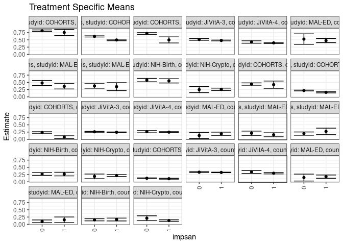

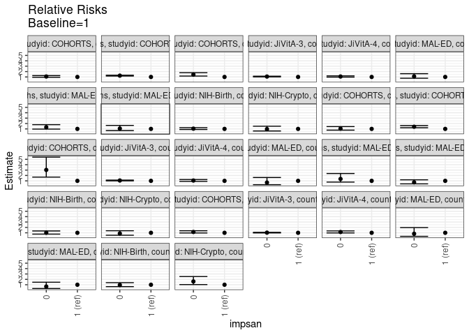

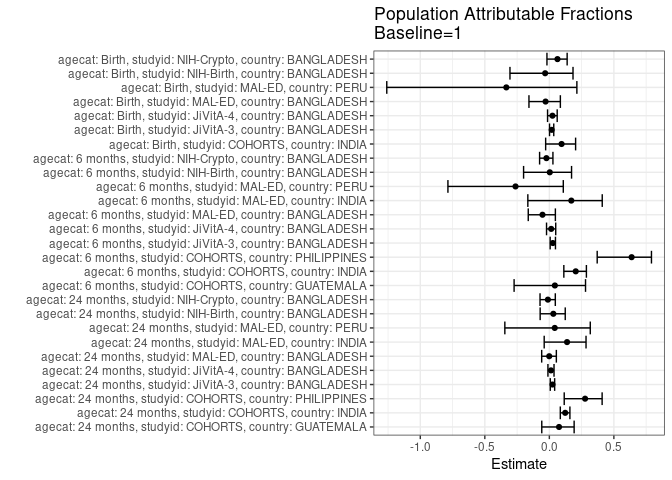

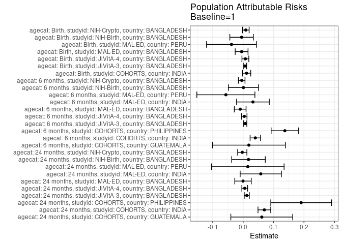

## Results Table

### Parameter: TSM

| agecat | studyid | country | intervention_level | baseline_level | estimate | ci_lower | ci_upper |
| --- | --- | --- | --- | --- | --- | --- | --- |
| Birth | COHORTS | INDIA | 1 | NA | 0.1070754 | 0.0910452 | 0.1231055 |
| Birth | COHORTS | INDIA | 0 | NA | 0.1232732 | 0.1113547 | 0.1351917 |
| Birth | JiVitA-3 | BANGLADESH | 1 | NA | 0.3232362 | 0.3139383 | 0.3325342 |
| Birth | JiVitA-3 | BANGLADESH | 0 | NA | 0.3326435 | 0.3175389 | 0.3477481 |
| Birth | JiVitA-4 | BANGLADESH | 1 | NA | 0.2961943 | 0.2732924 | 0.3190961 |
| Birth | JiVitA-4 | BANGLADESH | 0 | NA | 0.3391711 | 0.2905612 | 0.3877810 |
| Birth | MAL-ED | BANGLADESH | 1 | NA | 0.1787709 | 0.1225078 | 0.2350341 |
| Birth | MAL-ED | BANGLADESH | 0 | NA | 0.1470588 | 0.0277327 | 0.2663850 |
| Birth | MAL-ED | PERU | 1 | NA | 0.1538462 | 0.0555445 | 0.2521478 |
| Birth | MAL-ED | PERU | 0 | NA | 0.1025641 | 0.0548407 | 0.1502875 |
| Birth | NIH-Birth | BANGLADESH | 1 | NA | 0.1647040 | 0.1157274 | 0.2136805 |
| Birth | NIH-Birth | BANGLADESH | 0 | NA | 0.1559567 | 0.1189246 | 0.1929888 |
| Birth | NIH-Crypto | BANGLADESH | 1 | NA | 0.1299645 | 0.1037373 | 0.1561917 |
| Birth | NIH-Crypto | BANGLADESH | 0 | NA | 0.2089801 | 0.1249772 | 0.2929830 |
| 6 months | COHORTS | GUATEMALA | 1 | NA | 0.4203999 | 0.2947582 | 0.5460416 |
| 6 months | COHORTS | GUATEMALA | 0 | NA | 0.4412212 | 0.4010653 | 0.4813772 |
| 6 months | COHORTS | INDIA | 1 | NA | 0.1557043 | 0.1362941 | 0.1751144 |
| 6 months | COHORTS | INDIA | 0 | NA | 0.2186089 | 0.2039869 | 0.2332309 |
| 6 months | COHORTS | PHILIPPINES | 1 | NA | 0.0779593 | 0.0337211 | 0.1221975 |
| 6 months | COHORTS | PHILIPPINES | 0 | NA | 0.2360631 | 0.2088973 | 0.2632289 |
| 6 months | JiVitA-3 | BANGLADESH | 1 | NA | 0.2446183 | 0.2347245 | 0.2545122 |
| 6 months | JiVitA-3 | BANGLADESH | 0 | NA | 0.2600251 | 0.2442240 | 0.2758261 |
| 6 months | JiVitA-4 | BANGLADESH | 1 | NA | 0.2487755 | 0.2320541 | 0.2654969 |
| 6 months | JiVitA-4 | BANGLADESH | 0 | NA | 0.2629638 | 0.2251659 | 0.3007616 |
| 6 months | MAL-ED | BANGLADESH | 1 | NA | 0.1930693 | 0.1385244 | 0.2476142 |
| 6 months | MAL-ED | BANGLADESH | 0 | NA | 0.1315789 | 0.0238775 | 0.2392803 |
| 6 months | MAL-ED | INDIA | 1 | NA | 0.1566857 | 0.0876748 | 0.2256967 |
| 6 months | MAL-ED | INDIA | 0 | NA | 0.2117632 | 0.1392163 | 0.2843102 |
| 6 months | MAL-ED | PERU | 1 | NA | 0.2735315 | 0.1611848 | 0.3858781 |
| 6 months | MAL-ED | PERU | 0 | NA | 0.1986307 | 0.1428096 | 0.2544517 |
| 6 months | NIH-Birth | BANGLADESH | 1 | NA | 0.2672358 | 0.2051784 | 0.3292933 |
| 6 months | NIH-Birth | BANGLADESH | 0 | NA | 0.2689502 | 0.2216526 | 0.3162477 |
| 6 months | NIH-Crypto | BANGLADESH | 1 | NA | 0.2149741 | 0.1825275 | 0.2474206 |
| 6 months | NIH-Crypto | BANGLADESH | 0 | NA | 0.1873605 | 0.1063780 | 0.2683430 |
| 24 months | COHORTS | GUATEMALA | 1 | NA | 0.7539571 | 0.6478587 | 0.8600554 |
| 24 months | COHORTS | GUATEMALA | 0 | NA | 0.8160746 | 0.7893132 | 0.8428361 |
| 24 months | COHORTS | INDIA | 1 | NA | 0.4970811 | 0.4705761 | 0.5235861 |
| 24 months | COHORTS | INDIA | 0 | NA | 0.6193388 | 0.5992237 | 0.6394540 |
| 24 months | COHORTS | PHILIPPINES | 1 | NA | 0.4981137 | 0.3930835 | 0.6031439 |
| 24 months | COHORTS | PHILIPPINES | 0 | NA | 0.7204480 | 0.6900801 | 0.7508159 |
| 24 months | JiVitA-3 | BANGLADESH | 1 | NA | 0.4792271 | 0.4635674 | 0.4948869 |
| 24 months | JiVitA-3 | BANGLADESH | 0 | NA | 0.5145854 | 0.4862491 | 0.5429217 |
| 24 months | JiVitA-4 | BANGLADESH | 1 | NA | 0.3957093 | 0.3755196 | 0.4158990 |
| 24 months | JiVitA-4 | BANGLADESH | 0 | NA | 0.4269068 | 0.3859562 | 0.4678574 |
| 24 months | MAL-ED | BANGLADESH | 1 | NA | 0.4768514 | 0.4045977 | 0.5491051 |
| 24 months | MAL-ED | BANGLADESH | 0 | NA | 0.5272704 | 0.3464208 | 0.7081200 |
| 24 months | MAL-ED | INDIA | 1 | NA | 0.3642538 | 0.2723908 | 0.4561169 |
| 24 months | MAL-ED | INDIA | 0 | NA | 0.4774808 | 0.3892872 | 0.5656743 |
| 24 months | MAL-ED | PERU | 1 | NA | 0.3520312 | 0.2158347 | 0.4882278 |
| 24 months | MAL-ED | PERU | 0 | NA | 0.3760228 | 0.2977278 | 0.4543177 |
| 24 months | NIH-Birth | BANGLADESH | 1 | NA | 0.5511979 | 0.4781884 | 0.6242074 |
| 24 months | NIH-Birth | BANGLADESH | 0 | NA | 0.5780598 | 0.5193540 | 0.6367656 |
| 24 months | NIH-Crypto | BANGLADESH | 1 | NA | 0.2593396 | 0.2180044 | 0.3006749 |
| 24 months | NIH-Crypto | BANGLADESH | 0 | NA | 0.2491426 | 0.1457249 | 0.3525604 |

### Parameter: E(Y)

| agecat | studyid | country | intervention_level | baseline_level | estimate | ci_lower | ci_upper |
| --- | --- | --- | --- | --- | --- | --- | --- |
| Birth | COHORTS | INDIA | NA | NA | 0.1182998 | 0.1091394 | 0.1274602 |
| Birth | JiVitA-3 | BANGLADESH | NA | NA | 0.3291427 | 0.3217640 | 0.3365214 |
| Birth | JiVitA-4 | BANGLADESH | NA | NA | 0.3035461 | 0.2835868 | 0.3235054 |
| Birth | MAL-ED | BANGLADESH | NA | NA | 0.1737089 | 0.1227104 | 0.2247075 |
| Birth | MAL-ED | PERU | NA | NA | 0.1153846 | 0.0718621 | 0.1589071 |
| Birth | NIH-Birth | BANGLADESH | NA | NA | 0.1595395 | 0.1304091 | 0.1886699 |
| Birth | NIH-Crypto | BANGLADESH | NA | NA | 0.1386963 | 0.1134503 | 0.1639422 |
| 6 months | COHORTS | GUATEMALA | NA | NA | 0.4392097 | 0.4012606 | 0.4771588 |
| 6 months | COHORTS | INDIA | NA | NA | 0.1957353 | 0.1847045 | 0.2067660 |
| 6 months | COHORTS | PHILIPPINES | NA | NA | 0.2151431 | 0.1906585 | 0.2396277 |
| 6 months | JiVitA-3 | BANGLADESH | NA | NA | 0.2514286 | 0.2432891 | 0.2595681 |
| 6 months | JiVitA-4 | BANGLADESH | NA | NA | 0.2524352 | 0.2383740 | 0.2664965 |
| 6 months | MAL-ED | BANGLADESH | NA | NA | 0.1833333 | 0.1342773 | 0.2323893 |
| 6 months | MAL-ED | INDIA | NA | NA | 0.1888412 | 0.1384789 | 0.2392035 |
| 6 months | MAL-ED | PERU | NA | NA | 0.2167300 | 0.1668401 | 0.2666199 |
| 6 months | NIH-Birth | BANGLADESH | NA | NA | 0.2681564 | 0.2306532 | 0.3056597 |
| 6 months | NIH-Crypto | BANGLADESH | NA | NA | 0.2102273 | 0.1801065 | 0.2403480 |
| 24 months | COHORTS | GUATEMALA | NA | NA | 0.8152296 | 0.7897600 | 0.8406991 |
| 24 months | COHORTS | INDIA | NA | NA | 0.5667822 | 0.5509225 | 0.5826418 |
| 24 months | COHORTS | PHILIPPINES | NA | NA | 0.6888889 | 0.6600365 | 0.7177413 |
| 24 months | JiVitA-3 | BANGLADESH | NA | NA | 0.4911853 | 0.4780778 | 0.5042929 |
| 24 months | JiVitA-4 | BANGLADESH | NA | NA | 0.4008848 | 0.3839144 | 0.4178552 |
| 24 months | MAL-ED | BANGLADESH | NA | NA | 0.4764151 | 0.4090254 | 0.5438047 |
| 24 months | MAL-ED | INDIA | NA | NA | 0.4222222 | 0.3575415 | 0.4869030 |
| 24 months | MAL-ED | PERU | NA | NA | 0.3673469 | 0.2996839 | 0.4350100 |
| 24 months | NIH-Birth | BANGLADESH | NA | NA | 0.5687646 | 0.5218455 | 0.6156837 |
| 24 months | NIH-Crypto | BANGLADESH | NA | NA | 0.2564612 | 0.2182616 | 0.2946608 |

### Parameter: RR

| agecat | studyid | country | intervention_level | baseline_level | estimate | ci_lower | ci_upper |
| --- | --- | --- | --- | --- | --- | --- | --- |
| Birth | COHORTS | INDIA | 1 | 1 | 1.0000000 | 1.0000000 | 1.000000 |
| Birth | COHORTS | INDIA | 0 | 1 | 1.1512749 | 0.9636654 | 1.375409 |
| Birth | JiVitA-3 | BANGLADESH | 1 | 1 | 1.0000000 | 1.0000000 | 1.000000 |
| Birth | JiVitA-3 | BANGLADESH | 0 | 1 | 1.0291034 | 0.9775619 | 1.083363 |
| Birth | JiVitA-4 | BANGLADESH | 1 | 1 | 1.0000000 | 1.0000000 | 1.000000 |
| Birth | JiVitA-4 | BANGLADESH | 0 | 1 | 1.1450968 | 0.9735085 | 1.346929 |
| Birth | MAL-ED | BANGLADESH | 1 | 1 | 1.0000000 | 1.0000000 | 1.000000 |
| Birth | MAL-ED | BANGLADESH | 0 | 1 | 0.8226103 | 0.3445252 | 1.964117 |
| Birth | MAL-ED | PERU | 1 | 1 | 1.0000000 | 1.0000000 | 1.000000 |
| Birth | MAL-ED | PERU | 0 | 1 | 0.6666667 | 0.3024334 | 1.469562 |
| Birth | NIH-Birth | BANGLADESH | 1 | 1 | 1.0000000 | 1.0000000 | 1.000000 |
| Birth | NIH-Birth | BANGLADESH | 0 | 1 | 0.9468910 | 0.6476807 | 1.384328 |
| Birth | NIH-Crypto | BANGLADESH | 1 | 1 | 1.0000000 | 1.0000000 | 1.000000 |
| Birth | NIH-Crypto | BANGLADESH | 0 | 1 | 1.6079786 | 1.0258908 | 2.520341 |
| 6 months | COHORTS | GUATEMALA | 1 | 1 | 1.0000000 | 1.0000000 | 1.000000 |
| 6 months | COHORTS | GUATEMALA | 0 | 1 | 1.0495275 | 0.7697615 | 1.430973 |
| 6 months | COHORTS | INDIA | 1 | 1 | 1.0000000 | 1.0000000 | 1.000000 |
| 6 months | COHORTS | INDIA | 0 | 1 | 1.4040004 | 1.2198879 | 1.615900 |
| 6 months | COHORTS | PHILIPPINES | 1 | 1 | 1.0000000 | 1.0000000 | 1.000000 |
| 6 months | COHORTS | PHILIPPINES | 0 | 1 | 3.0280313 | 1.6969382 | 5.403245 |
| 6 months | JiVitA-3 | BANGLADESH | 1 | 1 | 1.0000000 | 1.0000000 | 1.000000 |
| 6 months | JiVitA-3 | BANGLADESH | 0 | 1 | 1.0629828 | 0.9930685 | 1.137819 |
| 6 months | JiVitA-4 | BANGLADESH | 1 | 1 | 1.0000000 | 1.0000000 | 1.000000 |
| 6 months | JiVitA-4 | BANGLADESH | 0 | 1 | 1.0570325 | 0.8992922 | 1.242441 |
| 6 months | MAL-ED | BANGLADESH | 1 | 1 | 1.0000000 | 1.0000000 | 1.000000 |
| 6 months | MAL-ED | BANGLADESH | 0 | 1 | 0.6815115 | 0.2866894 | 1.620074 |
| 6 months | MAL-ED | INDIA | 1 | 1 | 1.0000000 | 1.0000000 | 1.000000 |
| 6 months | MAL-ED | INDIA | 0 | 1 | 1.3515157 | 0.7726802 | 2.363972 |
| 6 months | MAL-ED | PERU | 1 | 1 | 1.0000000 | 1.0000000 | 1.000000 |
| 6 months | MAL-ED | PERU | 0 | 1 | 0.7261711 | 0.4424376 | 1.191862 |
| 6 months | NIH-Birth | BANGLADESH | 1 | 1 | 1.0000000 | 1.0000000 | 1.000000 |
| 6 months | NIH-Birth | BANGLADESH | 0 | 1 | 1.0064152 | 0.7562282 | 1.339373 |
| 6 months | NIH-Crypto | BANGLADESH | 1 | 1 | 1.0000000 | 1.0000000 | 1.000000 |
| 6 months | NIH-Crypto | BANGLADESH | 0 | 1 | 0.8715492 | 0.5519775 | 1.376139 |
| 24 months | COHORTS | GUATEMALA | 1 | 1 | 1.0000000 | 1.0000000 | 1.000000 |
| 24 months | COHORTS | GUATEMALA | 0 | 1 | 1.0823888 | 0.9373035 | 1.249932 |
| 24 months | COHORTS | INDIA | 1 | 1 | 1.0000000 | 1.0000000 | 1.000000 |
| 24 months | COHORTS | INDIA | 0 | 1 | 1.2459512 | 1.1726008 | 1.323890 |
| 24 months | COHORTS | PHILIPPINES | 1 | 1 | 1.0000000 | 1.0000000 | 1.000000 |
| 24 months | COHORTS | PHILIPPINES | 0 | 1 | 1.4463526 | 1.1677771 | 1.791383 |
| 24 months | JiVitA-3 | BANGLADESH | 1 | 1 | 1.0000000 | 1.0000000 | 1.000000 |
| 24 months | JiVitA-3 | BANGLADESH | 0 | 1 | 1.0737818 | 1.0113169 | 1.140105 |
| 24 months | JiVitA-4 | BANGLADESH | 1 | 1 | 1.0000000 | 1.0000000 | 1.000000 |
| 24 months | JiVitA-4 | BANGLADESH | 0 | 1 | 1.0788395 | 0.9676749 | 1.202775 |
| 24 months | MAL-ED | BANGLADESH | 1 | 1 | 1.0000000 | 1.0000000 | 1.000000 |
| 24 months | MAL-ED | BANGLADESH | 0 | 1 | 1.1057332 | 0.7623378 | 1.603811 |
| 24 months | MAL-ED | INDIA | 1 | 1 | 1.0000000 | 1.0000000 | 1.000000 |
| 24 months | MAL-ED | INDIA | 0 | 1 | 1.3108462 | 0.9618125 | 1.786541 |
| 24 months | MAL-ED | PERU | 1 | 1 | 1.0000000 | 1.0000000 | 1.000000 |
| 24 months | MAL-ED | PERU | 0 | 1 | 1.0681517 | 0.6923960 | 1.647826 |
| 24 months | NIH-Birth | BANGLADESH | 1 | 1 | 1.0000000 | 1.0000000 | 1.000000 |
| 24 months | NIH-Birth | BANGLADESH | 0 | 1 | 1.0487336 | 0.8918857 | 1.233165 |
| 24 months | NIH-Crypto | BANGLADESH | 1 | 1 | 1.0000000 | 1.0000000 | 1.000000 |
| 24 months | NIH-Crypto | BANGLADESH | 0 | 1 | 0.9606810 | 0.6159623 | 1.498319 |

### Parameter: PAR

| agecat | studyid | country | intervention_level | baseline_level | estimate | ci_lower | ci_upper |
| --- | --- | --- | --- | --- | --- | --- | --- |
| Birth | COHORTS | INDIA | 1 | NA | 0.0112245 | -0.0024910 | 0.0249400 |
| Birth | JiVitA-3 | BANGLADESH | 1 | NA | 0.0059065 | 0.0005242 | 0.0112887 |
| Birth | JiVitA-4 | BANGLADESH | 1 | NA | 0.0073518 | -0.0039628 | 0.0186665 |
| Birth | MAL-ED | BANGLADESH | 1 | NA | -0.0050620 | -0.0261785 | 0.0160544 |
| Birth | MAL-ED | PERU | 1 | NA | -0.0384615 | -0.1204726 | 0.0435496 |
| Birth | NIH-Birth | BANGLADESH | 1 | NA | -0.0051645 | -0.0437946 | 0.0334656 |
| Birth | NIH-Crypto | BANGLADESH | 1 | NA | 0.0087318 | -0.0021914 | 0.0196549 |
| 6 months | COHORTS | GUATEMALA | 1 | NA | 0.0188098 | -0.1011045 | 0.1387242 |
| 6 months | COHORTS | INDIA | 1 | NA | 0.0400310 | 0.0228627 | 0.0571993 |
| 6 months | COHORTS | PHILIPPINES | 1 | NA | 0.1371839 | 0.0919497 | 0.1824181 |
| 6 months | JiVitA-3 | BANGLADESH | 1 | NA | 0.0068103 | 0.0016574 | 0.0119631 |
| 6 months | JiVitA-4 | BANGLADESH | 1 | NA | 0.0036598 | -0.0053164 | 0.0126359 |
| 6 months | MAL-ED | BANGLADESH | 1 | NA | -0.0097360 | -0.0290616 | 0.0095896 |
| 6 months | MAL-ED | INDIA | 1 | NA | 0.0321555 | -0.0216106 | 0.0859215 |
| 6 months | MAL-ED | PERU | 1 | NA | -0.0568014 | -0.1522663 | 0.0386635 |
| 6 months | NIH-Birth | BANGLADESH | 1 | NA | 0.0009206 | -0.0486420 | 0.0504832 |
| 6 months | NIH-Crypto | BANGLADESH | 1 | NA | -0.0047468 | -0.0156050 | 0.0061114 |
| 24 months | COHORTS | GUATEMALA | 1 | NA | 0.0612725 | -0.0405305 | 0.1630755 |
| 24 months | COHORTS | INDIA | 1 | NA | 0.0697011 | 0.0487308 | 0.0906714 |
| 24 months | COHORTS | PHILIPPINES | 1 | NA | 0.1907752 | 0.0909243 | 0.2906262 |
| 24 months | JiVitA-3 | BANGLADESH | 1 | NA | 0.0119582 | 0.0036350 | 0.0202814 |
| 24 months | JiVitA-4 | BANGLADESH | 1 | NA | 0.0051755 | -0.0042598 | 0.0146107 |
| 24 months | MAL-ED | BANGLADESH | 1 | NA | -0.0004363 | -0.0274825 | 0.0266099 |
| 24 months | MAL-ED | INDIA | 1 | NA | 0.0579684 | -0.0098416 | 0.1257783 |
| 24 months | MAL-ED | PERU | 1 | NA | 0.0153157 | -0.1039918 | 0.1346232 |
| 24 months | NIH-Birth | BANGLADESH | 1 | NA | 0.0175666 | -0.0375768 | 0.0727101 |
| 24 months | NIH-Crypto | BANGLADESH | 1 | NA | -0.0028784 | -0.0180512 | 0.0122944 |

### Parameter: PAF

| agecat | studyid | country | intervention_level | baseline_level | estimate | ci_lower | ci_upper |
| --- | --- | --- | --- | --- | --- | --- | --- |
| Birth | COHORTS | INDIA | 1 | NA | 0.0948816 | -0.0285738 | 0.2035191 |
| Birth | JiVitA-3 | BANGLADESH | 1 | NA | 0.0179450 | 0.0014352 | 0.0341818 |
| Birth | JiVitA-4 | BANGLADESH | 1 | NA | 0.0242198 | -0.0138046 | 0.0608181 |
| Birth | MAL-ED | BANGLADESH | 1 | NA | -0.0291409 | -0.1579815 | 0.0853646 |
| Birth | MAL-ED | PERU | 1 | NA | -0.3333333 | -1.2598233 | 0.2133112 |
| Birth | NIH-Birth | BANGLADESH | 1 | NA | -0.0323712 | -0.3051573 | 0.1834009 |
| Birth | NIH-Crypto | BANGLADESH | 1 | NA | 0.0629561 | -0.0185539 | 0.1379432 |
| 6 months | COHORTS | GUATEMALA | 1 | NA | 0.0428265 | -0.2731320 | 0.2803723 |
| 6 months | COHORTS | INDIA | 1 | NA | 0.2045160 | 0.1122894 | 0.2871608 |
| 6 months | COHORTS | PHILIPPINES | 1 | NA | 0.6376400 | 0.3707833 | 0.7913203 |
| 6 months | JiVitA-3 | BANGLADESH | 1 | NA | 0.0270862 | 0.0063011 | 0.0474366 |
| 6 months | JiVitA-4 | BANGLADESH | 1 | NA | 0.0144978 | -0.0217236 | 0.0494352 |
| 6 months | MAL-ED | BANGLADESH | 1 | NA | -0.0531053 | -0.1634147 | 0.0467451 |
| 6 months | MAL-ED | INDIA | 1 | NA | 0.1702778 | -0.1666319 | 0.4098919 |
| 6 months | MAL-ED | PERU | 1 | NA | -0.2620837 | -0.7859079 | 0.1080977 |
| 6 months | NIH-Birth | BANGLADESH | 1 | NA | 0.0034331 | -0.1996431 | 0.1721324 |
| 6 months | NIH-Crypto | BANGLADESH | 1 | NA | -0.0225793 | -0.0755186 | 0.0277541 |
| 24 months | COHORTS | GUATEMALA | 1 | NA | 0.0751598 | -0.0586919 | 0.1920885 |
| 24 months | COHORTS | INDIA | 1 | NA | 0.1229768 | 0.0849595 | 0.1594147 |
| 24 months | COHORTS | PHILIPPINES | 1 | NA | 0.2769318 | 0.1153111 | 0.4090266 |
| 24 months | JiVitA-3 | BANGLADESH | 1 | NA | 0.0243456 | 0.0072273 | 0.0411687 |
| 24 months | JiVitA-4 | BANGLADESH | 1 | NA | 0.0129101 | -0.0109687 | 0.0362249 |
| 24 months | MAL-ED | BANGLADESH | 1 | NA | -0.0009158 | -0.0593289 | 0.0542763 |
| 24 months | MAL-ED | INDIA | 1 | NA | 0.1372935 | -0.0398979 | 0.2842927 |
| 24 months | MAL-ED | PERU | 1 | NA | 0.0416927 | -0.3448588 | 0.3171381 |
| 24 months | NIH-Birth | BANGLADESH | 1 | NA | 0.0308856 | -0.0711680 | 0.1232162 |
| 24 months | NIH-Crypto | BANGLADESH | 1 | NA | -0.0112234 | -0.0721462 | 0.0462375 |